# Coursera PML Class Project

Donald J Reilly

Sunday, April 26, 2015

This is the Practical Machine Learning Coursera Class Project. The following paragraphs are the given assignment.

Background

Using devices such as Jawbone Up, Nike FuelBand, and Fitbit it is now possible to collect a large amount of data about personal activity relatively inexpensively. These type of devices are part of the quantified self movement – a group of enthusiasts who take measurements about themselves regularly to improve their health, to find patterns in their behavior, or because they are tech geeks. One thing that people regularly do is quantify how much of a particular activity they do, but they rarely quantify how well they do it. In this project, your goal will be to use data from accelerometers on the belt, forearm, arm, and dumbell of 6 participants. They were asked to perform barbell lifts correctly and incorrectly in 5 different ways. More information is available from the website here: http://groupware.les.inf.puc-rio.br/har (see the section on the Weight Lifting Exercise Dataset).

Data

The training data for this project are available here:

https://d396qusza40orc.cloudfront.net/predmachlearn/pml-training.csv

The test data are available here:

https://d396qusza40orc.cloudfront.net/predmachlearn/pml-testing.csv

The data for this project come from this source: http://groupware.les.inf.puc-rio.br/har. If you use the document you create for this class for any purpose please cite them as they have been very generous in allowing their data to be used for this kind of assignment.

The methodology followed for this assignment is straightforward.

Load the data:

```r
library(AppliedPredictiveModeling)
library(rattle)
library(caret)
```

```r
library(ggplot2)
library(rpart)
library(rpart.plot)
#setwd("./Coursera R/Practical Machine Learning/Class Project")

# Load training and testing datasets
pml_training <- read.csv("pml-training.csv")
pml_testing <-read.csv("pml-testing.csv")
```

Some data scrubbing was required due to missing values in the data provided.

```r
# Cut out unused columns in the training and testing data frames
Keeps_training <- c("X", "user_name", "raw_timestamp_part_1", "raw_timestamp_part_2",
           "new_window", "num_window", "roll_belt", "pitch_belt", "yaw_belt", "total_accel_belt",
           "gyros_belt_x", "gyros_belt_y", "gyros_belt_z", "accel_belt_x", "accel_belt_y", "accel_belt_z",
           "magnet_belt_x", "magnet_belt_y", "magnet_belt_z","roll_arm", "pitch_arm", "yaw_arm", "total_accel_arm",
           "gyros_arm_x", "gyros_arm_y", "gyros_arm_z", "accel_arm_x", "accel_arm_y", "accel_arm_z", "magnet_arm_x",
           "magnet_arm_y", "magnet_arm_z", "roll_dumbbell", "pitch_dumbbell", "yaw_dumbbell", "total_accel_dumbbell",
           "gyros_dumbbell_x", "gyros_dumbbell_y", "gyros_dumbbell_z", "accel_dumbbell_x",
           "accel_dumbbell_y", "accel_dumbbell_z", "magnet_dumbbell_x", "magnet_dumbbell_y",
           "magnet_dumbbell_z", "roll_forearm", "pitch_forearm", "yaw_forearm", "total_accel_forearm",
           "gyros_forearm_x", "gyros_forearm_y", "gyros_forearm_z", "accel_forearm_x", "accel_forearm_y", "accel_forearm_z",
           "magnet_forearm_x", "magnet_forearm_y", "magnet_forearm_z", "classe")
pml_training <- pml_training[, Keeps_training, drop=TRUE]

Keeps_testing <- c("X", "user_name", "raw_timestamp_part_1", "raw_timestamp_part_2",
                   "new_window", "num_window", "roll_belt", "pitch_belt", "yaw_belt", "total_accel_belt",
                   "gyros_belt_x", "gyros_belt_y", "gyros_belt_z", "accel_belt_x", "accel_belt_y", "accel_belt_z",
                   "magnet_belt_x", "magnet_belt_y", "magnet_belt_z","roll_arm", "pitch_arm", "yaw_arm", "total_accel_arm",
                   "gyros_arm_x", "gyros_arm_y", "gyros_arm_z", "accel_arm_x", "accel_arm_y", "accel_arm_z", "magnet_arm_x",
                   "magnet_arm_y", "magnet_arm_z", "roll_dumbbell", "pitch_dumbbell", "yaw_dumbbell", "total_accel_dumbbell",
                   "gyros_dumbbell_x", "gyros_dumbbell_y", "gyros_dumbbell_z", "accel_dumbbell_x",
                   "accel_dumbbell_y", "accel_dumbbell_z", "magnet_dumbbell_x", "magnet_dumbbell_y",
                   "magnet_dumbbell_z", "roll_forearm", "pitch_forearm", "yaw_forearm", "total_accel_forearm",
                   "gyros_forearm_x", "gyros_forearm_y", "gyros_forearm_z", "accel_forearm_x", "accel_forearm_y", "accel_forearm_z",
                   "magnet_forearm_x", "magnet_forearm_y", "magnet_forearm_z", "problem_id")
pml_testing <-pml_testing[, Keeps_testing, drop=TRUE]
```

```r
# Create Validation dataset from training dataset
inTrain <- createDataPartition(y=pml_training$classe, p=0.95, list=FALSE)
training <- pml_training[inTrain,]
validation <- pml_training[-inTrain,]
dim(training); dim(validation); dim(pml_testing)
```

```
## [1] 18643    59
```

```
## [1] 979  59
```

```
## [1] 20 59
```

```r
set.seed(5151)
modelFit <- train(classe ~ ., data=validation, method="rf", prox=TRUE)
modelFit
```

```
## Random Forest
##
## 979 samples
##  58 predictor
##   5 classes: 'A', 'B', 'C', 'D', 'E'
##
## No pre-processing
## Resampling: Bootstrapped (25 reps)
##
## Summary of sample sizes: 979, 979, 979, 979, 979, 979, ...
##
## Resampling results across tuning parameters:
##
##   mtry  Accuracy   Kappa      Accuracy SD  Kappa SD
##    2    0.9372418  0.9204558  0.013312321  0.016805070
##   32    0.9949475  0.9936030  0.003466693  0.004393234
##   62    0.9929307  0.9910482  0.003220577  0.004075719
##
## Accuracy was used to select the optimal model using  the largest value.
## The final value used for the model was mtry = 32.
```

```r
print(modelFit$finalModel)
```

```
##
## Call:
##  randomForest(x = x, y = y, mtry = param$mtry, proximity = TRUE)
##                Type of random forest: classification
##                      Number of trees: 500
## No. of variables tried at each split: 32
##
##         OOB estimate of  error rate: 0.1%
## Confusion matrix:
##     A   B   C   D   E class.error
## A 278   1   0   0   0 0.003584229
## B   0 189   0   0   0 0.000000000
## C   0   0 171   0   0 0.000000000
## D   0   0   0 160   0 0.000000000
## E   0   0   0   0 180 0.000000000
```

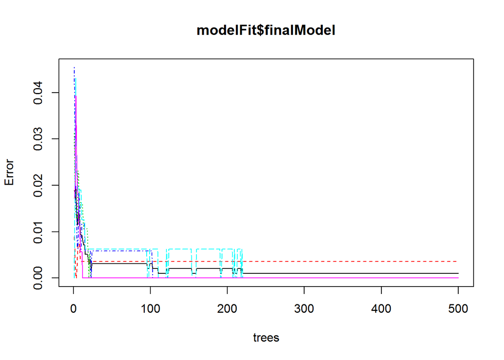

```r
plot(modelFit$finalModel)
```

And then to run the model against the test data set to provide the predicted outcomes that have not yet been predicted.

```r
pred <- predict(modelFit, pml_testing)
pred
```

```
##  [1] A A A A A A A A A A A A A A A A A A A A
## Levels: A B C D E
```